# RNA-seq

# Referencias

- Grigore, F., Yang, H., Hanson, N. D., VanBrocklin, M. W., Sarver, A. L., & Robinson, J. P. (2020). BRAF inhibition in melanoma is associated with the dysregulation of histone methylation and histone methyltransferases. Neoplasia, 22(9), 376-389.

- NL Bray, H Pimentel, P Melsted and L Pachter, Near optimal probabilistic RNA-seq quantification, Nature Biotechnology 34, p 525--527 (2016).

# Día 3

**Agenda:**

- Pipeline: Dónde estamos

- Importación e integración de datos
  - Ejercicio

- Normalización

- Corrección de _batches_
  - Exploración de datos con PCA

# Preguntas

- The GFF3 (General Feature Format) format consists of one line per feature, each containing 9 columns of data . [see more](http://www.ensembl.org/info/website/upload/gff3.html)

- The GTF (General Transfer Format) is identical to GFF version 2. [see more](http://www.ensembl.org/info/website/upload/gff.html)

- GitHub Max Storage (FREE) : 2GB

[figure not shown]

# Pipeline: Dónde estamos

[figure not shown]

_modified from (Villaseñor-Altamirano AB, 2021)_

Nuestro proyecto se ve algo así hasta ahora:

[figure not shown]

Ver archivo:

```bash
cd /mnt/Timina/bioinfoii/rnaseq
less out/kallisto/SRR12038081/abundance.tsv
```

# Importación e Integración de datos

[figure not shown]

Paquetes bioconductor: `tximeta` y [`tximport`](https://bioconductor.org/packages/devel/bioc/vignettes/tximport/inst/doc/tximport.html)

[figure not shown]

# Ejercicio

**Summarizing to gene level from transcript abundance with `tximport`**

```bash
screen -S txi
qlogin
cd [su/path/en/cluster]
cd out/kallisto/
module load r/4.0.2
R
```

En R:

```r
library(tximport)
library(tidyverse) # stringr

# Load data
files <- file.path("/mnt/Timina/bioinfoII/rnaseq/out/kallisto",list.dirs(dir2counts),"abundance.h5") # abundance files paths
names(files) <- str_extract(files,"SRR\\d+") # so that tximport identifies them
files
```

```
                                                         SRR12038081
"/mnt/Timina/bioinfoII/rnaseq/out/kallisto/SRR12038081/abundance.h5"
                                                         SRR12038082
"/mnt/Timina/bioinfoII/rnaseq/out/kallisto/SRR12038082/abundance.h5"
                                                         SRR12038083
"/mnt/Timina/bioinfoII/rnaseq/out/kallisto/SRR12038083/abundance.h5"
                                                         SRR12038084
"/mnt/Timina/bioinfoII/rnaseq/out/kallisto/SRR12038084/abundance.h5"
                                                         SRR12038085
"/mnt/Timina/bioinfoII/rnaseq/out/kallisto/SRR12038085/abundance.h5"
                                                         SRR12038086
"/mnt/Timina/bioinfoII/rnaseq/out/kallisto/SRR12038086/abundance.h5"
```

```r
# Load table with trx id and gene id corrspondence
tx2gene <- read.csv("/mnt/Timina/bioinfoII/rnaseq/resources/gencode/gencode.v38.basic.pc.transcripts.enstid_ensgid-nover.csv",stringsAsFactors = F)
# Load table with trx id and gene name corrspondence
tx2genename <- read.csv("/mnt/Timina/bioinfoII/rnaseq/resources/gencode/gencode.v38.basic.pc.transcripts.enstid_genename-nover.csv",stringsAsFactors = F)

# Run tximport
# tx2gene links transcript IDs to gene IDs for summarization
txi.kallisto <- tximport(files, type = "kallisto", tx2gene = tx2gene, ignoreAfterBar=TRUE, ignoreTxVersion=TRUE)
txi.kallisto.name <- tximport(files, type = "kallisto", tx2gene = tx2genename, ignoreAfterBar=TRUE, ignoreTxVersion=TRUE)
```

```
1 2 3 4 5 6
removing duplicated transcript rows from tx2gene
transcripts missing from tx2gene: 92813
summarizing abundance
summarizing counts
summarizing length
```

```r
names(txi.kallisto)
```

```
[1] "abundance"           "counts"              "length"
[4] "countsFromAbundance"
```

```r
head(txi.kallisto$counts)
```

[output not shown]

transcript estimation --> read counts

# Normalización

### ¿Por qué es necesario normalizar?

Nuestros datos están sujetos a **sesgos técnicos y biológicos** que provocan variabilidad en las cuentas.

Si queremos hacer **comparaciones de niveles de expresión entre muestras** es necesario ajustar los datos tomando en cuenta estos sesgos.

- Análisis de expresión diferencial
- Visualización de datos
- en general, siempre que estemos comparando expresión

### ¿Qué es normalizar en sí?

El proceso de ajuste de las cuentas (scaling factors) por los sesgos "no interesantes" de varibialidad.

## Criterios o sesgos a considerar

- Pueden ser relevantes para la comparacion de la expresión entre muestras distintas (eg muestra control vs muestra caso) y/o dentro de una misma muestra muestras (entre genes).

- __Sequencing depth__ : En este caso, cada gen parece expresarse el doble cuando comparamos `Sample A` vs `Sample B`, sin embargo, sólo parece a sí porque la `Sample A` tuvo el doble de secuenciación

- entre muestras distintas

[figure not shown]

## Criterios o sesgos a considerar

- __Sequencing depth__

- **Método:** Dividir por el size factor

[figure not shown]

## Criterios o sesgos a considerar

- __Gene length__ : El `Gene X` y el `Gene Y` tienen tienen niveles similares de expresión pero el número de lecturas mapeadas será mayor en el `Gen X` porque es más largo.

- misma muestra
  - Método: dividir por el largo del gen

[figure not shown]

## Criterios o sesgos a considerar

- __Composición de RNA__ : Si normalizamos dividiendo las cuentas entre el numero total de cuentas en cada muestra, el resto de los genes en la Sample A se verán ampliamente afectados por el Gene DE

- entre muestras distintas

- Genes altamente diferencialmente expresados

- Diferencias en el número de genes expresados -- PCR

- Contaminación

[figure not shown]

[figure not shown]

# Corrección por _batch effect_

**Mal diseño experimental  ==>  Mucho _batch effect_**

- En este caso no se podría tener certeza sobre ningún resultado

[figure not shown]

## Corrección por _batch effect_

**Buen diseño experimental, pero aun puede haber variación técnica**

[figure not shown]

## Corrección por _batch effect_

¡Pero no todo está perdido!

[figure not shown]

# Métodos de ajuste para RNA-seq

- `edgeR`
- `ComBat -batch`
- `ComBat_seq -batch -bio_conditions` :
    - Supone una binomial negativa

[figure not shown]

# Visualización de datos reales

[figure not shown]

- Balance entre integración de datasets para ganar poder estadístico y la capacidad de los algoritmos por deshacerse del _batch effect_

# Referencias

- Soneson, C., Love, M. I., & Robinson, M. D. (2015). Differential analyses for RNA-seq: transcript-level estimates improve gene-level inferences. F1000Research, 4.

- Meeta Mistry, R. K. (2017, April 26). Count normalization with deseq2. Introduction to DGE - ARCHIVED. Retrieved March 3, 2022, from https://hbctraining.github.io/DGE_workshop/lessons/02_DGE_count_normalization.html

- Zhang, Y., Parmigiani, G., & Johnson, W. E. (2020). ComBat-seq: batch effect adjustment for RNA-seq count data. NAR genomics and bioinformatics, 2(3), lqaa078.

# Día 4

**Agenda:**

- Pipeline: Dónde estamos
  - Ejercicio: Normalización de DESeq2
  - Ejercicio: Visualización de datos

- Análisis de Expresión Diferencial
  - Ejercicio con `DESeq2`

- Análisis Funcional

# Pipeline: Dónde estamos

[figure not shown]

- Leer detalles de experimento
- Los programas trabajan con el input que le das

ver sge de `kallisto quant`:

```bash
less /mnt/Citosina/amedina/mpadilla/clases/rnaseq/out/kallistoh/quant.sge
```

```
kallisto quant -i /mnt/Citosina/amedina/mpadilla/resources/kallisto/index_kallisto45_gencode38_hsapiens_cds -o ./SRR12038081 ../trimmed/SRR12038081*
```

# Normalización con DESEq2

- Normalización para DE: ajuste por

-  Composición de RNA y _Sequencing depth_

- `DESeq2` ajusta a un modelo lineal generalizado (GLM) de la familia binomial negativa (NB).

```
## # A tibble: 2 x 3
##   gene  muestraA muestraB
##   <chr>    <dbl>    <dbl>
## 1 gene1     1749      943
## 2 gene2       35       29
```

- Crea una pseudo-referencia por muestra (promedio geometrico por fila)

`\({\bar {x}}={\sqrt[{n}]{\prod _{i=1}^{n}{x_{i}}}}={\sqrt[{n}]{x_{1}\cdot x_{2}\cdots x_{n}}}\)`

```
## # A tibble: 2 x 4
## # Rowwise:
##   gene  muestraA muestraB prom_geom
##   <chr>    <dbl>    <dbl>     <dbl>
## 1 gene1     1749      943    1284.
## 2 gene2       35       29      31.9
```

Se calcula la fracción `\(muestraN/prom-gem\)`

```
## # A tibble: 2 x 6
## # Rowwise:
##   gene  muestraA muestraB prom_geom muestraA_pseudo_ref muestraB_pseudo_ref
##   <chr>    <dbl>    <dbl>     <dbl>               <dbl>               <dbl>
## 1 gene1     1749      943    1284.                 1.36               0.734
## 2 gene2       35       29      31.9                1.10               0.910
```

Se calcula un factor de normalización (size factor) utilizando la mediana por columnas.

```
## [1] 1.230235
## [1] 0.8222689
```

Se dividen las `\(cuentas-crudas/size-factor\)` para calcular las cuentas normalizadas.

```
## # A tibble: 2 x 3
## # Rowwise:
##   gene  muestraA muestraB
##   <chr>    <dbl>    <dbl>
## 1 gene1     1749      943
## 2 gene2       35       29
```

```
## # A tibble: 2 x 2
## # Rowwise:
##   norm_muestraA norm_muestraB
##           <dbl>         <dbl>
## 1        1422.         1147.
## 2          28.4          35.3
```

_tomado de (Vilaseñor-Altamirano AB, 2021)_

# Otras transformaciones

Puedes realizar otras transformaciones en `DESeq2` para estabilizar la varianza a través de los differentes valores promedio de expresión.

- Variance stabilizing transformation `vst` (n < 30 )
  - Regularized-logarithm transformation (rlog)

Propósito: visualización

[figure not shown]

Los genes con menor expresión tienen más varianza.

[figure not shown]

_Slide tomada de (Villaseñor-Altamirano, 2021)_

# Análisis de Expresión Diferencial

**¿La diferencia de expresión entre controles vs caso es significativa?**

[figure not shown]

# Análisis de Expresión Diferencial

**¿La diferencia de expresión entre controles vs caso es significativa?**

[figure not shown]

# Ejercicio: Normalización y DE con `DESeq2`

- input: un-normalized, count (or estimated count/fragments) data in the form of a matrix of integer values

```r
getwd()
```

```
[1] "/mnt/Citosina/amedina/mpadilla/clases/rnaseq"
```

Generar matriz de cuentas con `tximport` (Vease slide 39)

```r
library(tximport)
library(tidyverse) # stringr
# ajustar esta línea porque estoy parada en otro dir
files <- file.path("/mnt/Timina/bioinfoII/rnaseq",list.dirs("out/kallistoh"),"abundance.h5")[-1]
names(files) <- str_extract(files,"SRR\\d+")
# Load table with trx id and gene id corrspondence
tx2gene <- read.csv("/mnt/Timina/bioinfoII/rnaseq/resources/gencode/gencode.v38.basic.pc.transcripts.enstid_ensgid-nover.csv",stringsAsFactors = F)
# Generar matriz
txi.kallisto <- tximport(files, type = "kallisto", tx2gene = tx2gene, ignoreAfterBar=TRUE, ignoreTxVersion=TRUE)
txi.kallisto$counts %>% head
```

[output not shown]

DESeq2 requiere conocer cuáles muestras son controles y cuáles son los casos

- Añadimos información de nuestro experimento a.k.a. `metadata`

```r
samples <- read.csv("/mnt/Timina/bioinfoII/rnaseq/data/metadata/samples.csv",stringsAsFactors = F, header = TRUE) # obtained parsing file on SRA Run Selector
samples <- column_to_rownames(samples, var = "sample")
samples
```

```
            cell_line  genotype          org     type condition
SRR12038081      M14s BRAFV600E Homo_sapiens Melanoma untreated
SRR12038082      M14s BRAFV600E Homo_sapiens Melanoma untreated
SRR12038083      M14s BRAFV600E Homo_sapiens Melanoma untreated
SRR12038084      M14s BRAFV600E Homo_sapiens Melanoma Verafinib
SRR12038085      M14s BRAFV600E Homo_sapiens Melanoma Verafinib
SRR12038086      M14s BRAFV600E Homo_sapiens Melanoma Verafinib
```

Construir objeto `DESeqDataSet`, definir modelo de DE (especififcar controles y casos)

- Datos introducidos como modelo estadístico (formula de diseño)

```r
library(DESeq2)

dds <- DESeqDataSetFromTximport(txi.kallisto,
                                   colData = samples,
                                   design = ~ condition) # + si hay vars en condiciones
```

```
using counts and average transcript lengths from tximport
Warning message:
In DESeqDataSet(se, design = design, ignoreRank) :
  some variables in design formula are characters, converting to factors
```

```r
dds
```

[output not shown]

Normalización y Expresión Diferencial con `DESeq2` :

```r
# Prefiltrado para quitar genes con cuentas bajas
keep <- rowSums(counts(dds)) >= 6
dds <- dds[keep, ]

dds$condition <- factor(dds$condition, levels = c("untreated","Verafinib"))

dds <- DESeq(dds)
```

```
estimating size factors
using 'avgTxLength' from assays(dds), correcting for library size
estimating dispersions
gene-wise dispersion estimates
mean-dispersion relationship
final dispersion estimates
fitting model and testing
```

```r
# use contrast= parameter if design formula has > 2 levels
res <- results(dds)
res
```

[output not shown]

[figure not shown]

## Visualización de datos usando `PCA`

[figure not shown]

_imagen tomada de (Villaseñor-Altamirano, 2021)_

# Visualización usando Volcano Plots

[figure not shown]

# Análisis Funcional

Gene Ontology (GO term) Enrichment Analysis

- `EnrichR`, `TopGO`, `Gprofiler`, `GORilla`
- Databases
- Ejemplo:

[figure not shown]

# RNA-seq, ¿qué pensamos ahora?

**Actividad:** Lluvia de ideas

[figure not shown]

- Llenen en la siguiente tabla palabras clave sobre RNA-seq: https://docs.google.com/document/d/1pAFddzDlLrRvHMSUjddh7EG3PdTbob3g9UQWzMHXR-w/edit?usp=sharing

- Generemos una [figura de nuestras ideas](https://www.r-graph-gallery.com/wordcloud.html):

```r
library(wordcloud)
library(RColorBrewer)

words <- c("Expresióndiferencial","comparación de medias","sesgos","control de calidad","pipeline ","análisis funcional ExpresiónDiferencial","PCA","Transcripción","Batch effect","Counts.RNA","secuenciación","proteínas","regulación","expresióngénica","expresión diferencial","normalización","sequencing depthTranscriptoma","RNA","expresióndiferencial","conteo","normalización","Volcano plot","batch effect","sesgos","composición de RNA","tamaño del gen","sequencing depth","alineamiento","Expresiondiferencial","pipeline","normalizacion","transcriptoma","matriz de cuentas","size factor","transcritos","algoritmosTranscriptoma","expresión","diferenciación","sesgos","PCA","significancia","normalización","alineamiento","genomade referenciaExpresion","exones","transcriptoma","UTR","hisat2","splicing","DE","normalizacion","volcanoplot","PCA")

wordcloud(words, colors = RColorBrewer::brewer.pal(5,name = "BuPu"))
```

[figure not shown]

# Referencias

http://bioconductor.org/packages/release/workflows/vignettes/rnaseqGene/inst/doc/rnaseqGene.html

https://biocorecrg.github.io/CRG_RIntroduction/volcano-plots.html

# Gracias!

[figure not shown]

# Día 5

**Agenda:**

- Revisitar resultados de DEA
  - MAplot
  - Volcano plot con ggplot
  - heatmap

- Enriquecimiento funcional de términos GO
  - Ejercicio con gprofiler

# Resultados DE

- DESeq2 performs for each gene a hypothesis test to see whether evidence is sufficient to decide against the null hypothesis that there is zero effect of the treatment on the gene and that the observed difference between treatment and control was merely caused by experimental variability (i.e., the type of variability that you can expect between different samples in the same treatment group).

```r
res
```

```
log2 fold change (MLE): condition Verafinib vs untreated
Wald test p-value: condition Verafinib vs untreated
DataFrame with 12371 rows and 6 columns
                  baseMean log2FoldChange     lfcSE      stat      pvalue
                 <numeric>      <numeric> <numeric> <numeric>   <numeric>
ENSG000000000035  53.15332      -2.328062  1.310704 -1.776192 7.57013e-02
ENSG000000004194   4.51349       1.076738  1.046573  1.028822 3.03563e-01
ENSG000000004574  12.51881      -0.393507  1.191887 -0.330155 7.41283e-01
ENSG000000004607  17.76331      -2.630115  1.230373 -2.137657 3.25446e-02
ENSG000000009716  62.32683       5.396259  0.685695  7.869768 3.55299e-15
...                    ...            ...       ...       ...         ...
ENSG00000288699    6.85454      -2.502914  2.723702 -0.918938   0.3581278
ENSG00000288701  255.71582       0.450524  0.239893  1.878017   0.0603788
ENSG00000288709    1.37077      -0.413138  3.674915 -0.112421   0.9104894
ENSG00000288710    4.21706       1.528236  2.526702  0.604834   0.5452892
ENSG00000288722   13.09369      -0.151997  0.783592 -0.193974   0.8461960
                        padj
                   <numeric>
ENSG000000000035 2.53340e-01
ENSG000000004194 5.69300e-01
ENSG000000004574 8.90212e-01
ENSG000000004607 1.46951e-01
ENSG000000009716 1.12924e-12
...                      ...
ENSG00000288699     0.625206
ENSG00000288701     0.219065
ENSG00000288709           NA
ENSG00000288710     0.768360
ENSG00000288722     0.940957
```

```r
summary(res) # if we consider a fraction of 10% false positives acceptable, we can consider all genes with an adjusted p value below 10% = 0.1 as significant
```

```r
out of 12371 with nonzero total read count
adjusted p-value < 0.1
LFC > 0 (up)       : 944, 7.6%
LFC < 0 (down)     : 1072, 8.7%
outliers [1]       : 47, 0.38%
low counts [2]     : 1200, 9.7%
(mean count < 2)
[1] see 'cooksCutoff' argument of ?results
[2] see 'independentFiltering' argument of ?results
```

Aplicar un filtro más estricto:

- Lower the false discovery rate threshold (the threshold on `padj` in the results table)

```r
res.05 <- results(dds, alpha = 0.05)
table(res.05$padj < 0.05) # genes that rejected null hypothesis
```

```
FALSE  TRUE
 9462  1423
```

```r
summary(res.05)
```

```
out of 12371 with nonzero total read count
adjusted p-value < 0.05
LFC > 0 (up)       : 670, 5.4%
LFC < 0 (down)     : 753, 6.1%
outliers [1]       : 47, 0.38%
low counts [2]     : 1439, 12%
(mean count < 2)
```

- Raise the log2 fold change threshold from 0 using the `lfcThreshold` argument of results
  - test for genes that show more substantial changes due to treatment
  - `lfcThreshold = 1`, we test for genes that show significant effects of treatment on gene counts more than doubling or less than halving, because 2^1=2

```r
resLFC1 <- results(dds, lfcThreshold=1)
table(resLFC1$padj < 0.1)
```

```
FALSE  TRUE
10284   361
```

```r
summary(resLFC1)
```

```
out of 12371 with nonzero total read count
adjusted p-value < 0.1
LFC > 1.00 (up)    : 181, 1.5%
LFC < -1.00 (down) : 180, 1.5%
outliers [1]       : 47, 0.38%
low counts [2]     : 1679, 14%
(mean count < 3)
[1] see 'cooksCutoff' argument of ?results
[2] see 'independentFiltering' argument of ?results
```

Aplicar filtro `padj < 0.1` en el dataset:

```r
resSig <- subset(res, padj < 0.1) # subset
head(resSig[ order(resSig$log2FoldChange), ]) # more downregulated genes
```

```
log2 fold change (MLE): condition Verafinib vs untreated
Wald test p-value: condition Verafinib vs untreated
DataFrame with 6 rows and 6 columns
                  baseMean log2FoldChange     lfcSE      stat      pvalue
                 <numeric>      <numeric> <numeric> <numeric>   <numeric>
ENSG000001700062  599.8734      -10.88831   2.03420  -5.35264 8.66813e-08
ENSG000001783812  104.3246      -10.52935   2.74355  -3.83785 1.24114e-04
ENSG00000095752    77.5441      -10.14965   1.56211  -6.49739 8.17275e-11
ENSG000001056403  665.6523       -9.98499   1.83063  -5.45440 4.91382e-08
ENSG000000771521  710.0401       -9.12275   1.82720  -4.99274 5.95298e-07
ENSG00000268465   121.3530       -9.00081   2.47916  -3.63059 2.82774e-04
                        padj
                   <numeric>
ENSG000001700062 6.26132e-06
ENSG000001783812 2.62480e-03
ENSG00000095752  1.16556e-08
ENSG000001056403 3.87669e-06
ENSG000000771521 3.14560e-05
ENSG00000268465  4.98508e-03
```

```r
head(resSig[ order(resSig$log2FoldChange, decreasing = TRUE), ]) # genes more upregulated
```

```
                  baseMean log2FoldChange     lfcSE      stat      pvalue
                 <numeric>      <numeric> <numeric> <numeric>   <numeric>
ENSG000001685426  137.5806       10.11793   1.22756   8.24234 1.68876e-16
ENSG00000224389   130.2751       10.04003   1.28036   7.84158 4.44909e-15
ENSG00000171819   122.2740        9.94837   1.23095   8.08183 6.38028e-16
ENSG000001002013   47.2760        8.54354   1.28972   6.62433 3.48825e-11
ENSG00000180447    41.6446        8.39529   1.25613   6.68346 2.33359e-11
ENSG000001977795   12.0566        8.01497   2.84050   2.82168 4.77734e-03
                        padj
                   <numeric>
ENSG000001685426 7.22530e-14
ENSG00000224389  1.37477e-12
ENSG00000171819  2.44739e-13
ENSG000001002013 5.54333e-09
ENSG00000180447  3.76215e-09
ENSG000001977795 4.11325e-02
```

# Ejercicio: MA plot

Un MA plot (Dudoit et al. 2002) es un tipo de scatter plot que permite visualizar e identificar los cambios en niveles de expresión de dos condiciones diferentes (caso/tratado vs control).
- `y-axis` **M (minus)** log fold change
- `x-axis` **A (average)** log of the mean of normalized expression counts of two conditions
- a.k.a. _mean-difference_ plot, _Bland-Altman_ plot

Usaremos la función `lfcShrink` para encoger los _log2 fold changes_ para facilitar la comparación de genes que:
- Son poco abundantes
- Tienen alta dispersión

```r
library(apeglm) # good for shrinking the noisy LFC estimates while giving low bias LFC estimates for true large differences (Zhu, Ibrahim, and Love 2018)
resultsNames(dds) # ver comparaciones
```

```
[1] "Intercept"                        "condition_Verafinib_vs_untreated"
```

```r
resLFC <- lfcShrink(dds, coef="condition_Verafinib_vs_untreated", type="apeglm")
resLFC
```

Generar MAplot:

```r
# definir dir donde vamos a guardar plots (ya creados)
outdir = "/mnt/Citosina/amedina/mpadilla/clases/rnaseq/results/maplot/"

# generar plot y guadar
# resultados completos
png(file = paste0(outdir,"maplot01-res-noshrink.png"),
    width = 800, height = 800) # guardar el plot en formato png
plotMA(res, ylim = c(-5, 5)) # funcion de DESeq
dev.off()

# resultados genes significativos
png(file = paste0(outdir,"maplot01-resSig-noshrink.png"),
    width = 800, height = 800) # guardar el plot en formato png
plotMA(resSig, ylim = c(-5, 5)) # funcion de DESeq
dev.off()

# resultados con lfcShrink
png(file = paste0(outdir,"maplot01-resLFC-shrink.png"),
    width = 800, height = 800) # guardar el plot en formato png
plotMA(resLFC, ylim = c(-5, 5)) # funcion de DESeq
dev.off()

# resaltar gen mas significatvo
png(file = paste0(outdir,"maplot02-res-noshrink.png"),
    width = 800, height = 800) # guardar el plot en formato png
plotMA(res, ylim = c(-5,5)) # lo mismo que antes
topGene <- rownames(res)[which.min(res$padj)] # tomar gen con menos pval adjusted
with(res[topGene, ], { # with evalua las expresiones dadas en el objeto dado
  points(baseMean, log2FoldChange, col="dodgerblue", cex=2, lwd=2) # le damos las coordenadas y especificaciones de estilo
  text(baseMean, log2FoldChange, topGene, pos=2, col="dodgerblue") # coordenadas y estilo
})
dev.off()
```

Abrir plot en compu local:

```bash
rsync -rptuvl mpadilla@dna.liigh.unam.mx:/mnt/Citosina/amedina/mpadilla/clases/rnaseq/results/maplot/* plots/
xdg-open plots/maplot01-res-noshrink.png
```

[figure not shown]

```bash
xdg-open plots/maplot01-resSig-noshrink.png
```

[figure not shown]

```bash
xdg-open plots/maplot02-res-noshrink.png
```

[figure not shown]

# Ejercicio: Volcano plot

Tipo de scatter plot que representa la expresión diferencial (en este caso de genes).
  - `x-axis` fold change
  - `y-axis` p-value

```r
library(ggplot2) # cargamos librería

outdir = "/mnt/Citosina/amedina/mpadilla/clases/rnaseq/results/volcano/"
png(file = paste0(outdir,"volcano01-res.png"),
    width = 800, height = 800) # guardar el plot en formato png

# The basic scatter plot: x is "log2FoldChange", y is "pvalue"
ggplot(data=as.data.frame(res), aes(x=log2FoldChange, y=pvalue)) +
* geom_point() # scatter plot

dev.off()
```

[figure not shown]

...looks quite ugly. ¿Qué hacemos para mejorar la visualización?

```r
png(file = paste0(outdir,"volcano02-res.png"),
    width = 800, height = 800) # guardar el plot en formato png

ggplot(data=as.data.frame(res), aes(x=log2FoldChange, y=-log10(pvalue))) +
  geom_point() # scatter plot

dev.off()
```

[figure not shown]

```r
png(file = paste0(outdir,"volcano03-res.png"),
    width = 800, height = 800) # guardar el plot en formato png

ggplot(data=as.data.frame(res), aes(x=log2FoldChange, y=-log10(pvalue))) +
  geom_point() + # scatter plot
* theme_minimal() + # tema de fondo
* geom_vline(xintercept=c(-0.6, 0.6), col="red") + # vertical lines for log2FoldChange thresholds
* geom_hline(yintercept=-log10(0.05), col="red") + # horizontal line for the p-value threshold
* xlim(-15,15)

dev.off()
```

[figure not shown]

Identificar por colores los genes diferencialmente expresados

```r
# Add a column to the data frame to specify if they are UP- or DOWN- regulated (log2FoldChange respectively positive or negative)
de <- as.data.frame(res)

# add a column of NAs
de$diffexpressed <- "NO"
# if log2Foldchange > 0.6 and pvalue < 0.05, set as "UP"
de$diffexpressed[de$log2FoldChange > 0.6 & de$pvalue < 0.05] <- "UP"
# if log2Foldchange < -0.6 and pvalue < 0.05, set as "DOWN"
de$diffexpressed[de$log2FoldChange < -0.6 & de$pvalue < 0.05] <- "DOWN"

png(file = paste0(outdir,"volcano04-res.png"),
    width = 800, height = 800) # guardar el plot en formato png

ggplot(data=de, aes(x=log2FoldChange, y=-log10(pvalue), col=diffexpressed)) + # cambiamos col param de aes
  geom_point() + theme_minimal() +
  geom_vline(xintercept=c(-0.6, 0.6), col="red") +
  geom_hline(yintercept=-log10(0.05), col="red") +
  xlim(-15,15)

dev.off()
```

[figure not shown]

Cambiar colores de puntos, escribir nombres de genes

```r
library(ggrepel) # libreria que evita el overlap de texto en labels

# Create a new column "names" to de, that will contain the name of a subset if genes differentially expressed (NA in case they are not)
de$names <- NA
# filter for a subset of interesting genes
filter <- which(de$diffexpressed != "NO" & de$padj < 0.05 & (de$log2FoldChange >= 9 | de$log2FoldChange <= -9))
de$names[filter] <- rownames(de)[filter]

# Generar y guardara plot
png(file = paste0(outdir,"volcano05-res.png"),
    width = 800, height = 800) # guardar el plot en formato png

ggplot(data=de, aes(x=log2FoldChange, y=-log10(pvalue), col=diffexpressed, label=names)) +
    geom_point() +
*   scale_color_manual(values=c("blue", "black", "red")) + # cambiar colores de puntos
    theme_minimal() +
*   geom_text_repel() +
    xlim(-15,15)

dev.off()
```

[figure not shown]

Practiquen cambiar otras cosas: labs, theme, titles, subtitles, colores de puntos, labels, etc.

Ideas de edición: http://www.r-graph-gallery.com/index.html

Referencia: https://biocorecrg.github.io/CRG_RIntroduction/volcano-plots.html

# Heatmap

- ¿Qué tipo de normalización deben tener los datos (cuentas) para visualizarlos en un heatmap?
  - vst() Para ajustar por la varianza de los genes, pues estaremos comparando genes y muestras
  - [Referencia de imagen y código: sección 6.3](http://bioconductor.org/packages/release/workflows/vignettes/rnaseqGene/inst/doc/rnaseqGene.html)

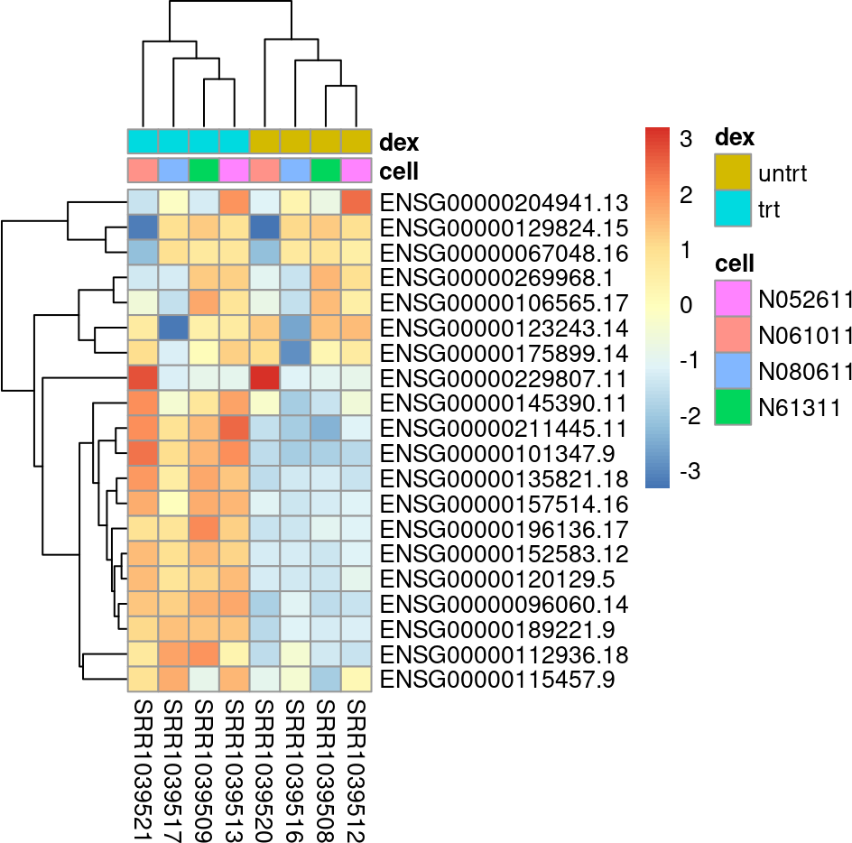

# Enriquecimiento funcional de términos GO

- [gprofiler2](https://cran.r-project.org/web/packages/gprofiler2/vignettes/gprofiler2.html)
- `gost` enables to perform functional profiling of gene lists. The function performs statistical enrichment analysis to find over-representation of functions from Gene Ontology, biological pathways like KEGG and Reactome, human disease annotations, etc. This is done with the hypergeometric test followed by correction for multiple testing.

```r
library(gprofiler2)
```

¿Cómo correr gost? [ver manual](https://cran.r-project.org/web/packages/gprofiler2/vignettes/gprofiler2.html)

```r
# subset results for genes of interest
resSig <- subset(res, padj < 0.1 & log2FoldChange > 1) # subset
resSig <- resSig[ order(resSig$log2FoldChange, decreasing = TRUE), ]

# define gene lists
DEG <- rownames(resSig)
#genes_universe <-

# enrichment analysis
gostres = gost(query = DEG, organism = "hsapiens", significant = T,
               correction_method = "fdr", domain_scope = "custom",
               custom_bg = genes_universe, ordered_query = TRUE)
names(gostres)
attributes(gostres$meta)
head(gostres$result)
```

```
    query significant      p_value term_size query_size intersection_size
1 query_1        TRUE 4.892300e-03         3          9                 3
2 query_1        TRUE 5.224098e-03         3          9                 3
3 query_1        TRUE 4.963271e-05        11        205                 9
4 query_1        TRUE 4.963271e-05         9        205                 8
5 query_1        TRUE 5.373725e-05        12        205                10
6 query_1        TRUE 1.865613e-04        10        205                 8
   precision    recall    term_id source
1 0.33333333 1.0000000 GO:2000427  GO:BP
2 0.33333333 1.0000000 GO:2000425  GO:BP
3 0.04390244 0.8181818 HP:0000576     HP
4 0.03902439 0.8888889 HP:0001112     HP
5 0.04878049 0.8333333 HP:0001427     HP
6 0.03902439 0.8000000 HP:0000631     HP
                                        term_name effective_domain_size
1 positive regulation of apoptotic cell clearance                  2676
2          regulation of apoptotic cell clearance                  2676
3                             Centrocecal scotoma                  2676
4                             Leber optic atrophy                  2676
5                       Mitochondrial inheritance                  2676
6                     Retinal arterial tortuosity                  2676
  source_order                            parents
1        29652 GO:0043277, GO:0050766, GO:2000425
2        29650             GO:0043277, GO:0050764
3          446                         HP:0000575
4          874                         HP:0000587
5         1073                         HP:0000005
6          492 HP:0000630, HP:0005116, HP:0012841
```

Generar Barplot

```r
library(forcats)

outdir = "/mnt/Citosina/amedina/mpadilla/clases/rnaseq/results/gost/"
go <- as.data.frame(gostres$result)

png(file = paste0(outdir,"gost01-resSig.png"),
    width = 800, height = 800) # guardar el plot en formato png
# Reorder following the value of another column:
go %>%
  arrange(p_value) %>% # order de acuerdo a valor incremental de pvalues
  select(term_name,p_value) %>%  # seleccionar cols de df
  dplyr::slice(1:20) %>% # tomar las primeas 20 filas
  mutate(go = fct_reorder(term_name, p_value)) %>%
  ggplot( aes(x=go, y=p_value)) +
    geom_bar(stat="identity", fill="#3A68AE", alpha=.6, width=.4) +
    coord_flip() +
    labs(x = "", y = "Adjusted P-value") +
    theme_bw(base_size = 20)

dev.off()
```

[figure not shown]

[kallisto]:https://pachterlab.github.io/kallisto/manual